# Lesson 21: Describing Bivariate Data; Scatterplots, Correlation, and Covariance

Homework

- Word Document
- PDF Document

## Solutions

**Please note that the steps show rounded numbers, but that the final answers to the problems are calculated without rounding.**

Problem

Part

Solution

1

-

Linear, moderate negative association.

2

-

Linear, strong positive association.

3

-

Linear, moderate positive association.

4

-

Nonlinear.

5

-

Linear, moderate positive association.

6

-

Linear, weak positive association.

7

-

c. There is a strong negative linear relationship between the variables.

8

-

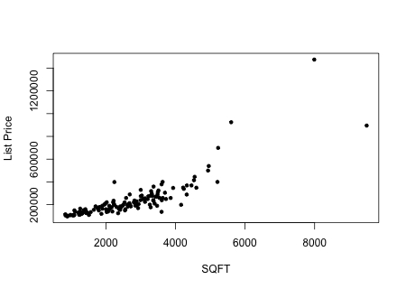

9

-

Answers will vary. One plausible answer is that it does appear to be linear, with a strong positive association. You may also see slight curve to the data.

10

-

$r = 0.843$

11

-

If in answer to question 9 you said that the data appear to show a strong positive association that is supported by $r = 0.843$ because it is a positive number and it is close to 1.

12

-

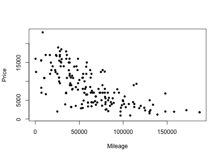

13

-

Answers will vary. One plausible answer is that it does appear to be linear, with a moderate negative association.

14

-

$r = -0.687$

15

-